# War, What Is It Good For?

Alec Engel

7/8/2021

In the world of baseball, there there have been many analytic formulas created to more realistically compare data of individual player performance. Here, our main sports analytics measure will be wins above replacement [(WAR)](https://www.mlb.com/glossary/advanced-stats/wins-above-replacement) for MLB pitchers in 2019. Per mlb.com for a pitcher, WAR represents a net rating of individual pitching aspects that shows how many more wins he is worth than a replacement-level pitcher. Individual ratings that make up this net rating include adjusted numbers based on whether they play in the National League or American League, and the difficulty of ballparks they pitch in. When these are plotted alongside innings pitched totals and against league averages, we can determine how many more wins a pitcher is worth than his replacement. They higher a pitcher’s WAR rating, the more valuable he is when playing in relation to his team’s success and winning games. We can use these WAR ratings to more easily compare current baseball pitchers, as well as pitchers from different generations.

Fielding Independent Pitching (FIP) is a component of WAR’s calculation in which a pitcher’s run prevention is estimated without the effects of their team’s defense. This allows for a more uniform statistic excluding defense, strikeouts, walks, hit by pitches and home runs allowed. This is basically another measure for earned runs against (ERA) but being independent of all other aspects of the game and isolating the pitcher’s performance. When looking at the relationship of FIP to WAR, we can clearly see a linear relationship in which lower FIP results in a pitcher’s WAR being greater.

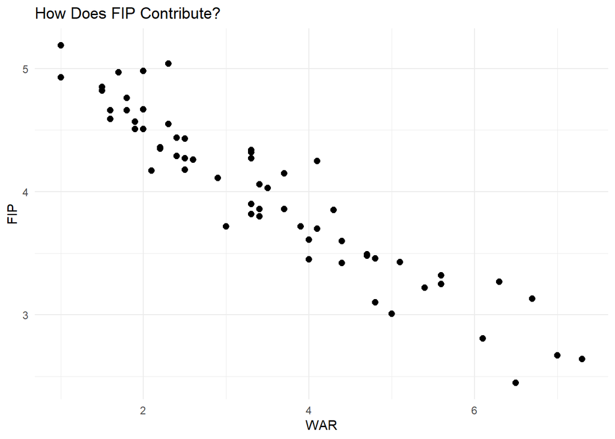

War measurements also look to be positively correlated to the amount of innings a pitcher plays. This makes perfect sense as you would leave a pitcher in the game if he is performing well, therefor increasing his WAR as he continues to pitch instead of his replacement.

Does it really matter how a pitcher gets his outs? Whether its a strikeout, a pop fly or a ground out, does it really matter? We can see in below’s visualiation that indeed the more strikeouts a pitcher has (size of data point), his WAR rating is increasing as well. We can see this in particular with top pitchers Garrit Cole, Max Scherzer and Justin Verlander.

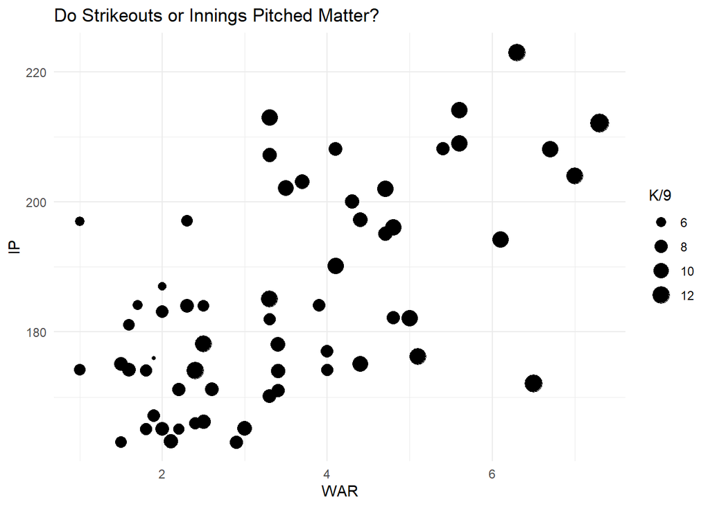

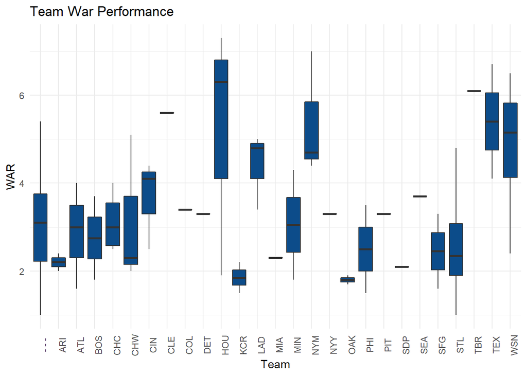

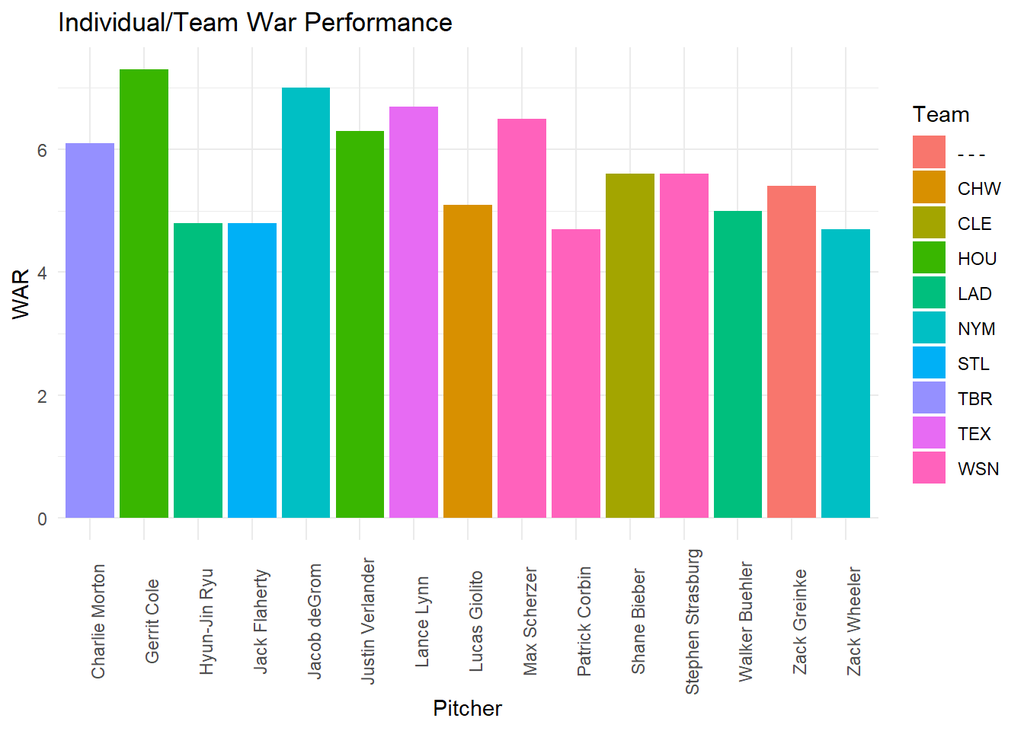

### WAR Under 2

| Name | Team | W | L | SV | G | GS | IP | K/9 | BB/9 | HR/9 | BABIP | LOB% | GB% | HR/FB | vFA (pi) | ERA | xERA | FIP | xFIP | WAR | playerid |
| --- | --- | --- | --- | --- | --- | --- | --- | --- | --- | --- | --- | --- | --- | --- | --- | --- | --- | --- | --- | --- | --- |
| Brett Anderson | OAK | 13 | 9 | 0 | 31 | 31 | 176 | 4.6 | 2.51 | 1.02 | 0.278 | 74.8% | 54.5% | 13.3% | 91.2 | 3.89 | 5.45 | 4.57 | 4.79 | 1.9 | 8223 |
| Wade Miley | HOU | 14 | 6 | 0 | 33 | 33 | 167.1 | 7.53 | 3.28 | 1.24 | 0.287 | 74.3% | 49.7% | 15.2% | 90.9 | 3.98 | 3.83 | 4.51 | 4.52 | 1.9 | 8779 |
| Martin Perez | MIN | 10 | 7 | 0 | 32 | 29 | 165.1 | 7.35 | 3.65 | 1.25 | 0.316 | 67.6% | 48.0% | 15.0% | 94.2 | 5.12 | 4.14 | 4.66 | 4.69 | 1.8 | 6902 |
| Rick Porcello | BOS | 14 | 12 | 0 | 32 | 32 | 174.1 | 7.38 | 2.32 | 1.6 | 0.308 | 65.7% | 38.1% | 13.1% | 91.1 | 5.52 | 4.83 | 4.76 | 5.14 | 1.8 | 2717 |
| Mike Fiers | OAK | 15 | 4 | 0 | 33 | 33 | 184.2 | 6.14 | 2.58 | 1.46 | 0.254 | 78.5% | 39.9% | 13.8% | 90.5 | 3.9 | 4.89 | 4.97 | 5.19 | 1.7 | 7754 |
| Julio Teheran | ATL | 10 | 11 | 0 | 33 | 33 | 174.2 | 8.35 | 4.28 | 1.13 | 0.266 | 76.6% | 39.0% | 11.2% | 89.8 | 3.81 | 4.83 | 4.66 | 5.26 | 1.6 | 6797 |
| Jeff Samardzija | SFG | 11 | 12 | 0 | 32 | 32 | 181.1 | 6.95 | 2.43 | 1.39 | 0.24 | 76.9% | 36.4% | 12.6% | 91.7 | 3.52 | 4.76 | 4.59 | 5.02 | 1.6 | 3254 |
| Jakob Junis | KCR | 9 | 14 | 0 | 31 | 31 | 175.1 | 8.42 | 2.98 | 1.59 | 0.318 | 70.3% | 42.4% | 16.7% | 91.8 | 5.24 | 5.41 | 4.82 | 4.63 | 1.5 | 13619 |
| Zach Eflin | PHI | 10 | 13 | 0 | 32 | 28 | 163.1 | 7.11 | 2.64 | 1.54 | 0.291 | 73.9% | 44.4% | 16.0% | 94 | 4.13 | 4.05 | 4.85 | 4.76 | 1.5 | 13774 |
| Dakota Hudson | STL | 16 | 7 | 1 | 33 | 32 | 174.2 | 7.01 | 4.43 | 1.13 | 0.274 | 78.1% | 56.9% | 19.8% | 94.1 | 3.35 | 5.1 | 4.93 | 4.55 | 1 | 19206 |

[output cut: 1 more lines]

### WAR Over 5

| Name | Team | W | L | SV | G | GS | IP | K/9 | BB/9 | HR/9 | BABIP | LOB% | GB% | HR/FB | vFA (pi) | ERA | xERA | FIP | xFIP | WAR | playerid |
| --- | --- | --- | --- | --- | --- | --- | --- | --- | --- | --- | --- | --- | --- | --- | --- | --- | --- | --- | --- | --- | --- |
| Gerrit Cole | HOU | 20 | 5 | 0 | 33 | 33 | 212.1 | 13.82 | 2.03 | 1.23 | 0.275 | 83.3% | 40.3% | 16.9% | 97.3 | 2.5 | 2.44 | 2.64 | 2.48 | 7.3 | 13125 |
| Jacob deGrom | NYM | 11 | 8 | 0 | 32 | 32 | 204 | 11.25 | 1.94 | 0.84 | 0.282 | 81.8% | 44.4% | 11.2% | 97.1 | 2.43 | 2.59 | 2.67 | 3.11 | 7 | 10954 |
| Lance Lynn | TEX | 16 | 11 | 0 | 33 | 33 | 208.1 | 10.63 | 2.55 | 0.91 | 0.322 | 74.4% | 40.3% | 9.9% | 94.7 | 3.67 | 3.38 | 3.13 | 3.85 | 6.7 | 2520 |
| Max Scherzer | WSN | 11 | 7 | 0 | 27 | 27 | 172.1 | 12.69 | 1.72 | 0.94 | 0.321 | 78.7% | 40.8% | 11.6% | 95 | 2.92 | 2.83 | 2.45 | 2.88 | 6.5 | 3137 |
| Justin Verlander | HOU | 21 | 6 | 0 | 34 | 34 | 223 | 12.11 | 1.7 | 1.45 | 0.218 | 88.4% | 35.9% | 16.0% | 94.6 | 2.58 | 2.5 | 3.27 | 3.18 | 6.3 | 8700 |
| Charlie Morton | TBR | 16 | 6 | 0 | 33 | 33 | 194.2 | 11.1 | 2.64 | 0.69 | 0.298 | 75.2% | 48.2% | 10.4% | 94.8 | 3.05 | 3.3 | 2.81 | 3.28 | 6.1 | 4676 |
| Stephen Strasburg | WSN | 18 | 6 | 0 | 33 | 33 | 209 | 10.81 | 2.41 | 1.03 | 0.274 | 76.5% | 51.1% | 16.2% | 94.1 | 3.32 | 3.08 | 3.25 | 3.17 | 5.6 | 10131 |
| Shane Bieber | CLE | 15 | 8 | 0 | 34 | 33 | 214.1 | 10.88 | 1.68 | 1.3 | 0.296 | 77.4% | 43.9% | 16.1% | 93.2 | 3.28 | 3.64 | 3.32 | 3.23 | 5.6 | 19427 |
| Zack Greinke | - - - | 18 | 5 | 0 | 33 | 33 | 208.2 | 8.07 | 1.29 | 0.91 | 0.271 | 75.7% | 45.2% | 10.9% | 89.9 | 2.93 | 3.45 | 3.22 | 3.74 | 5.4 | 1943 |
| Lucas Giolito | CHW | 14 | 9 | 0 | 29 | 29 | 176.2 | 11.62 | 2.9 | 1.22 | 0.273 | 77.7% | 36.0% | 13.6% | 94.4 | 3.41 | 3.45 | 3.43 | 3.66 | 5.1 | 15474 |

A pitcher’s WAR is extremely important in his teams success which is why so many scouts and baseball analytic personnel lean heavily on these numbers. It may even be the difference between a team missing or making the playoffs and a potential World Series Championship.